# Shrinkage and Regularized Regression

Connor Gilroy

2018-05-17

# Setup

```r
library("rstan")
library("loo")
library("glmnet")
library("tidyverse")
library("lasso2")

options(mc.cores = parallel::detectCores())
rstan_options(auto_write = TRUE)
```

# Data

We’re using data on prostate cancer, found in the `lasso2` package, for illustrative purposes only. Regularized regression is even more useful when you have more variables than this.

```r
data("Prostate", package = "lasso2")
f <- lpsa ~ lcavol + lweight + age + lbph + svi + lcp + gleason + pgg45 - 1L
prostate_data <- list(
  y = Prostate$lpsa,
  X = model.matrix(f, data = Prostate)
)

prostate_data$N <- nrow(prostate_data$X)
prostate_data$K <- ncol(prostate_data$X)
prostate_data$X <- scale(prostate_data$X)
```

# Ridge regression

In Bayesian ridge regression, the global scale parameter tau is inversely related to the parameter called lambda in `glmnet`.

```r
fit_ridge_glmnet <- cv.glmnet(x = prostate_data$X, y = prostate_data$y,
                              alpha = 0)
```

In the first version of the model, tau is fixed:

```r
mod_ridge1 <- stan_model("stan/ridge_regression_1.stan")
```

Try changing the value of tau:

```r
tau_values <- c(4, 2, 1, .5, .04)
fit_ridge1 <- sampling(mod_ridge1, data = c(prostate_data, tau = tau_values[1]))
# fit_ridge1 <- sampling(mod_ridge1, data = c(prostate_data, tau = tau_values[5]))
```

Compare the coefficients as tau gets smaller:

```r
print(fit_ridge1, pars = c("a", "b", "sigma"))
```

```
## Inference for Stan model: ridge_regression_1.
## 4 chains, each with iter=2000; warmup=1000; thin=1;
## post-warmup draws per chain=1000, total post-warmup draws=4000.
##
##        mean se_mean   sd  2.5%   25%   50%   75% 97.5% n_eff Rhat
## a      2.48       0 0.07  2.34  2.43  2.48  2.53  2.62  4000    1
## b[1]   0.69       0 0.10  0.48  0.62  0.69  0.76  0.90  4000    1
## b[2]   0.23       0 0.08  0.06  0.17  0.23  0.28  0.39  4000    1
## b[3]  -0.15       0 0.08 -0.31 -0.20 -0.15 -0.09  0.02  4000    1
## b[4]   0.16       0 0.09 -0.02  0.10  0.16  0.22  0.32  4000    1
## b[5]   0.32       0 0.11  0.11  0.25  0.32  0.39  0.53  4000    1
## b[6]  -0.15       0 0.13 -0.41 -0.23 -0.14 -0.05  0.11  4000    1
## b[7]   0.03       0 0.12 -0.20 -0.04  0.03  0.11  0.27  3665    1
## b[8]   0.13       0 0.13 -0.12  0.04  0.13  0.21  0.37  3794    1
## sigma  0.72       0 0.05  0.62  0.68  0.71  0.75  0.84  4000    1
##
## Samples were drawn using NUTS(diag_e) at Wed May 16 23:44:06 2018.
## For each parameter, n_eff is a crude measure of effective sample size,
## and Rhat is the potential scale reduction factor on split chains (at
## convergence, Rhat=1).
```

```
## ci_level: 0.8 (80% intervals)
```

```
## outer_level: 0.95 (95% intervals)
```

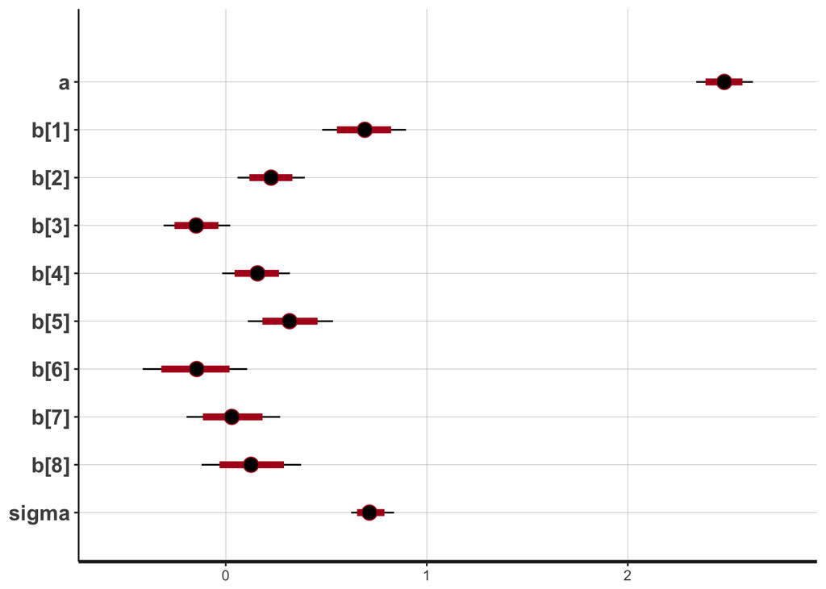

```r
plot(fit_ridge1, pars = c("a", "b", "sigma"))
```

In the second version, we actually treat tau as a model parameter, and put a prior on it:

```r
mod_ridge2 <- stan_model("stan/ridge_regression_2.stan")
fit_ridge2 <- sampling(mod_ridge2, data = prostate_data)
```

```r
print(fit_ridge2, pars = c("a", "b", "sigma", "tau"))
```

```
## Inference for Stan model: ridge_regression_2.
## 4 chains, each with iter=2000; warmup=1000; thin=1;
## post-warmup draws per chain=1000, total post-warmup draws=4000.
##
##        mean se_mean   sd  2.5%   25%   50%   75% 97.5% n_eff Rhat
## a      2.48       0 0.07  2.34  2.43  2.48  2.53  2.62  4000    1
## b[1]   0.62       0 0.10  0.41  0.55  0.62  0.68  0.82  4000    1
## b[2]   0.22       0 0.08  0.06  0.16  0.22  0.28  0.39  4000    1
## b[3]  -0.12       0 0.08 -0.28 -0.17 -0.12 -0.06  0.04  4000    1
## b[4]   0.14       0 0.08 -0.02  0.09  0.14  0.19  0.31  4000    1
## b[5]   0.29       0 0.10  0.10  0.23  0.29  0.35  0.48  4000    1
## b[6]  -0.07       0 0.12 -0.31 -0.15 -0.07  0.01  0.17  3550    1
## b[7]   0.04       0 0.10 -0.17 -0.03  0.04  0.11  0.24  4000    1
## b[8]   0.11       0 0.11 -0.12  0.03  0.10  0.18  0.33  3697    1
## sigma  0.72       0 0.06  0.62  0.68  0.72  0.75  0.84  4000    1
## tau    0.33       0 0.11  0.18  0.25  0.31  0.38  0.59  3161    1
##
## Samples were drawn using NUTS(diag_e) at Wed May 16 23:44:11 2018.
## For each parameter, n_eff is a crude measure of effective sample size,
## and Rhat is the potential scale reduction factor on split chains (at
## convergence, Rhat=1).
```

```
## ci_level: 0.8 (80% intervals)
```

```
## outer_level: 0.95 (95% intervals)
```

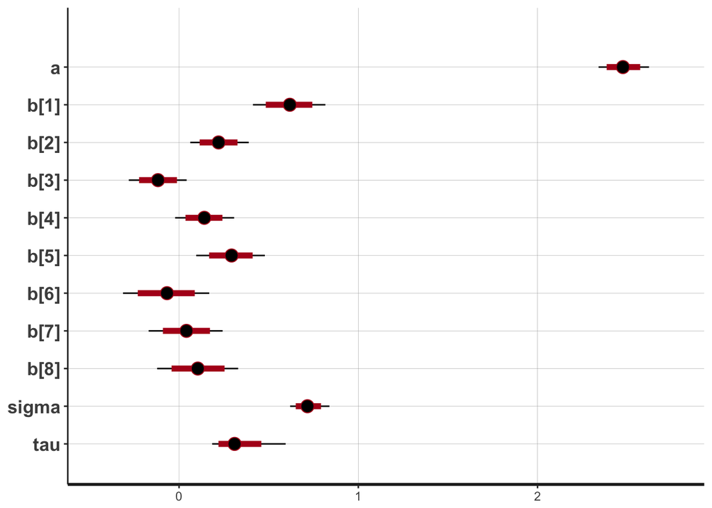

```r
plot(fit_ridge2, pars = c("a", "b", "sigma", "tau"))
```

# Lasso regression

Replace the normal priors on the coefficients with Laplace priors:

```r
mod_lasso1 <- stan_model("stan/lasso_regression_1.stan")
```

```r
tau_values <- c(4, 2, 1, .5, .04)
fit_lasso1 <- sampling(mod_lasso1, data = c(prostate_data, tau = tau_values[1]))
# fit_lasso1 <- sampling(mod_lasso1, data = c(prostate_data, tau = tau_values[5]))
```

```r
print(fit_lasso1, pars = c("a", "b", "sigma"))
```

```
## Inference for Stan model: lasso_regression_1.
## 4 chains, each with iter=2000; warmup=1000; thin=1;
## post-warmup draws per chain=1000, total post-warmup draws=4000.
##
##        mean se_mean   sd  2.5%   25%   50%   75% 97.5% n_eff Rhat
## a      2.48       0 0.07  2.34  2.43  2.48  2.53  2.62  4000    1
## b[1]   0.69       0 0.11  0.49  0.62  0.69  0.76  0.90  4000    1
## b[2]   0.22       0 0.08  0.06  0.16  0.22  0.28  0.39  4000    1
## b[3]  -0.14       0 0.08 -0.31 -0.20 -0.14 -0.09  0.02  4000    1
## b[4]   0.15       0 0.08 -0.01  0.10  0.16  0.21  0.32  4000    1
## b[5]   0.31       0 0.10  0.12  0.25  0.31  0.38  0.52  4000    1
## b[6]  -0.14       0 0.13 -0.39 -0.23 -0.15 -0.06  0.10  4000    1
## b[7]   0.03       0 0.11 -0.19 -0.04  0.03  0.11  0.25  4000    1
## b[8]   0.12       0 0.12 -0.12  0.04  0.12  0.21  0.36  3748    1
## sigma  0.72       0 0.06  0.62  0.68  0.72  0.75  0.83  4000    1
##
## Samples were drawn using NUTS(diag_e) at Wed May 16 23:44:15 2018.
## For each parameter, n_eff is a crude measure of effective sample size,
## and Rhat is the potential scale reduction factor on split chains (at
## convergence, Rhat=1).
```

```
## ci_level: 0.8 (80% intervals)
```

```
## outer_level: 0.95 (95% intervals)
```

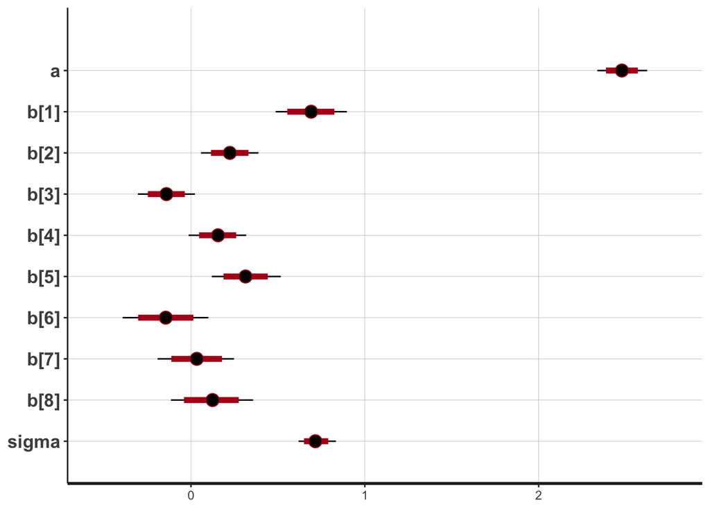

```r
plot(fit_lasso1, pars = c("a", "b", "sigma"))
```

```r
mod_lasso2 <- stan_model("stan/lasso_regression_2.stan")
fit_lasso2 <- sampling(mod_lasso2, data = prostate_data)
```

```r
print(fit_lasso2, pars = c("a", "b", "sigma", "tau"))
```

```
## Inference for Stan model: lasso_regression_2.
## 4 chains, each with iter=2000; warmup=1000; thin=1;
## post-warmup draws per chain=1000, total post-warmup draws=4000.
##
##        mean se_mean   sd  2.5%   25%   50%   75% 97.5% n_eff Rhat
## a      2.48       0 0.07  2.34  2.43  2.48  2.53  2.62  4000    1
## b[1]   0.64       0 0.10  0.44  0.57  0.64  0.71  0.84  4000    1
## b[2]   0.21       0 0.08  0.04  0.15  0.21  0.26  0.37  4000    1
## b[3]  -0.10       0 0.08 -0.26 -0.15 -0.09 -0.04  0.06  4000    1
## b[4]   0.13       0 0.08 -0.03  0.07  0.12  0.18  0.29  4000    1
## b[5]   0.27       0 0.10  0.08  0.20  0.27  0.34  0.47  3695    1
## b[6]  -0.05       0 0.11 -0.28 -0.12 -0.04  0.02  0.16  3229    1
## b[7]   0.03       0 0.09 -0.15 -0.03  0.03  0.09  0.22  2795    1
## b[8]   0.08       0 0.10 -0.10  0.01  0.08  0.15  0.29  2601    1
## sigma  0.72       0 0.05  0.62  0.68  0.72  0.75  0.83  4000    1
## tau    0.26       0 0.12  0.11  0.18  0.23  0.31  0.56  3382    1
##
## Samples were drawn using NUTS(diag_e) at Wed May 16 23:44:19 2018.
## For each parameter, n_eff is a crude measure of effective sample size,
## and Rhat is the potential scale reduction factor on split chains (at
## convergence, Rhat=1).
```

```
## ci_level: 0.8 (80% intervals)
```

```
## outer_level: 0.95 (95% intervals)
```

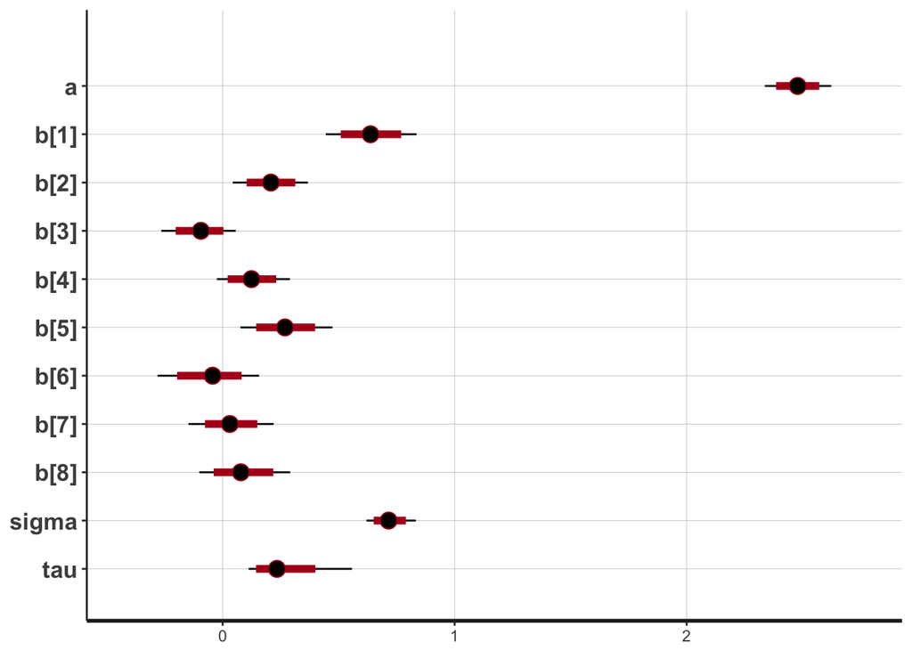

```r
plot(fit_lasso2, pars = c("a", "b", "sigma", "tau"))
```

# Regularization paths

In machine-learning lasso regression, some coefficients actually go to 0, so the paths look very different for ridge and for lasso. This doesn’t happen with the posterior distributions in the Bayesian lasso.

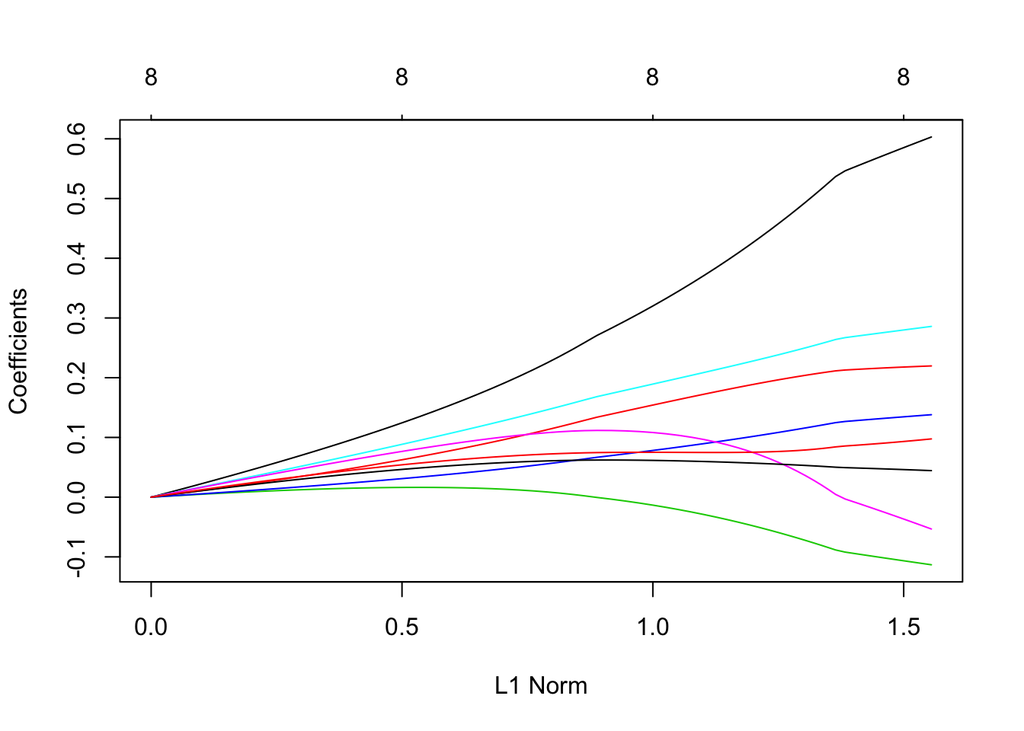

```r
p_ridge <- glmnet(x = prostate_data$X, y = prostate_data$y, alpha = 0)
p_lasso <- glmnet(x = prostate_data$X, y = prostate_data$y, alpha = 1)
plot(p_ridge)
```

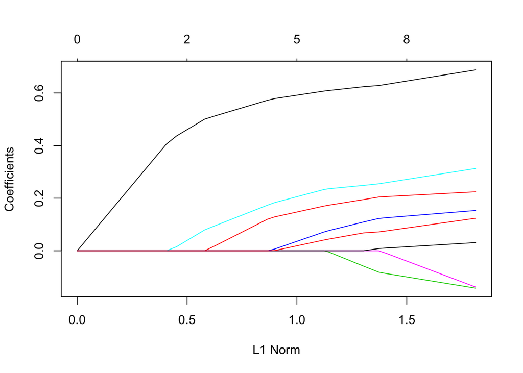

```r
plot(p_lasso)
```

# More sparsity: hierarchical shrinkage

We can use different global-local scale mixtures of normal distributions as our priors to encourage more sparsity. (The lasso, remember, is actually one of these too.)

We combine the global scale for the coefficient priors, tau, with a local scale lambda. (Sorry, there aren’t enough Greek letters to go around…)

$$\beta_{k} \sim Normal(0, \lambda_k \tau)$$

(Written Stan-style, so $\lambda_k \tau$ is the standard deviation.)

We draw those lambdas from some distribution.

$$\lambda_k \sim Cauchy^{+}(0, 1)$$

This is the “horseshoe” prior, one special case of the hierarchical shrinkage prior (`hs()` in `rstanarm`).

As usual, we can fix tau or put a prior on it:

```r
mod_hs1 <- stan_model("stan/hierarchical_shrinkage_1.stan")
mod_hs2 <- stan_model("stan/hierarchical_shrinkage_2.stan")
```

You can see that these models are harder to sample from, because they have more divergent transitions:

```r
fit_hs1 <- sampling(mod_hs1, data = c(prostate_data, tau = tau_values[4]),
                    control = list(adapt_delta = .999,
                                   max_treedepth = 15))
```

```
## Warning: There were 9 divergent transitions after warmup. Increasing adapt_delta above 0.999 may help. See
## http://mc-stan.org/misc/warnings.html#divergent-transitions-after-warmup
```

```
## Warning: Examine the pairs() plot to diagnose sampling problems
```

Increasing adapt_delta makes sampling slower, but even increasing it a great deal doesn’t prevent all divergent transitions in this case. http://mc-stan.org/misc/warnings.html#divergent-transitions-after-warmup

```
## ci_level: 0.8 (80% intervals)
```

```
## outer_level: 0.95 (95% intervals)
```

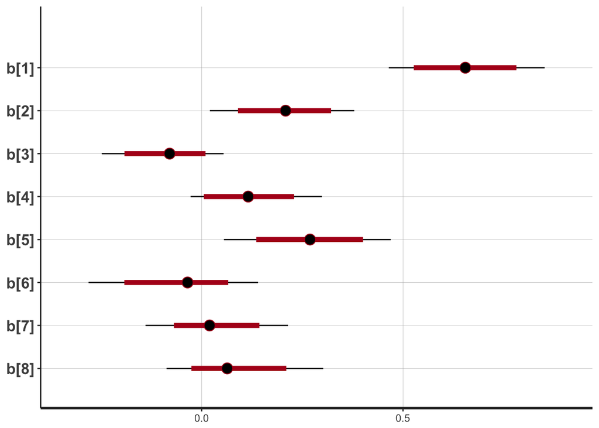

```r
plot(fit_hs1, pars = "b")
```

```
## ci_level: 0.8 (80% intervals)
## outer_level: 0.95 (95% intervals)
```

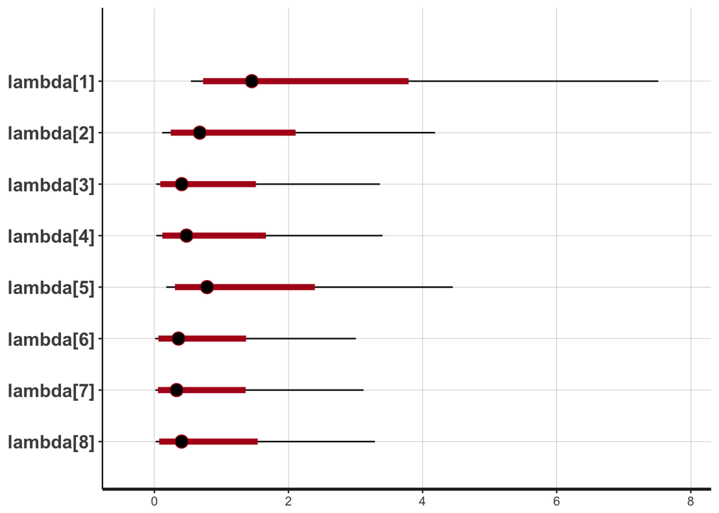

```r
plot(fit_hs1, pars = "lambda")
```

```r
fit_hs2 <- sampling(mod_hs2, data = prostate_data,
                    control = list(adapt_delta = .999,
                                   max_treedepth = 15))
```

```
## ci_level: 0.8 (80% intervals)
```

```
## outer_level: 0.95 (95% intervals)
```

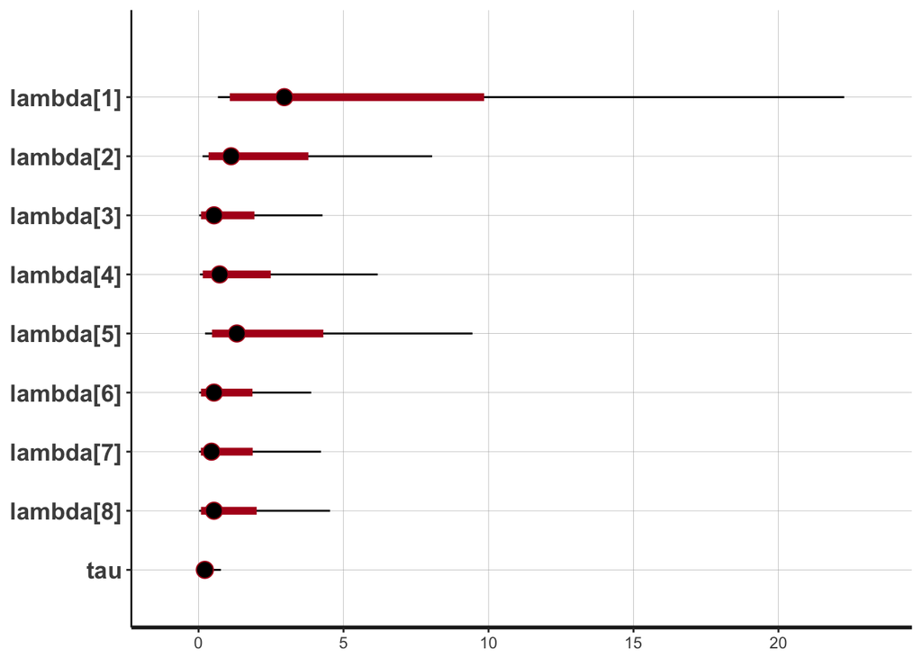

```r
plot(fit_hs2, pars = c("lambda", "tau"))
```